# DATA 621 Business Analytics & Data Mining

Homework 5 Poission & Negative Binomial Regression

Kyle Gilde

4/16/2018

# Overview

In this homework assignment, you will explore, analyze and model a data set containing information on approximately 12,000 commercially available wines. The variables are mostly related to the chemical properties of the wine being sold. The response variable is the number of sample cases of wine that were purchased by wine distribution companies after sampling a wine. These cases would be used to provide tasting samples to restaurants and wine stores around the United States. The more sample cases purchased, the more likely is a wine to be sold at a high end restaurant. A large wine manufacturer is studying the data in order to predict the number of wine cases ordered based upon the wine characteristics. If the wine manufacturer can predict the number of cases, then that manufacturer will be able to adjust their wine offering to maximize sales.

Your objective is to build a count regression model to predict the number of cases of wine that will be sold given certain properties of the wine.

# 1. DATA EXPLORATION

## Examine the cases & variables

After removing the `INDEX` column, the data set contains 15 numerical variables and 12,795 observations. Given that the `NA`s in the `STARS` variable are meaningful, we have changed those instances to zero to represent a very poor rating.

```
## 'data.frame':    12795 obs. of  15 variables:
##  $ TARGET            : int  3 3 5 3 4 0 0 4 3 6 ...
##  $ FixedAcidity      : num  3.2 4.5 7.1 5.7 8 11.3 7.7 6.5 14.8 5.5 ...
##  $ VolatileAcidity   : num  1.16 0.16 2.64 0.385 0.33 0.32 0.29 -1.22 0.27 -0.22 ...
##  $ CitricAcid        : num  -0.98 -0.81 -0.88 0.04 -1.26 0.59 -0.4 0.34 1.05 0.39 ...
##  $ ResidualSugar     : num  54.2 26.1 14.8 18.8 9.4 ...
##  $ Chlorides         : num  -0.567 -0.425 0.037 -0.425 NA 0.556 0.06 0.04 -0.007 -0.277 ...
##  $ FreeSulfurDioxide : num  NA 15 214 22 -167 -37 287 523 -213 62 ...
##  $ TotalSulfurDioxide: num  268 -327 142 115 108 15 156 551 NA 180 ...
##  $ Density           : num  0.993 1.028 0.995 0.996 0.995 ...
##  $ pH                : num  3.33 3.38 3.12 2.24 3.12 3.2 3.49 3.2 4.93 3.09 ...
##  $ Sulphates         : num  -0.59 0.7 0.48 1.83 1.77 1.29 1.21 NA 0.26 0.75 ...
##  $ Alcohol           : num  9.9 NA 22 6.2 13.7 15.4 10.3 11.6 15 12.6 ...
##  $ LabelAppeal       : int  0 -1 -1 -1 0 0 0 1 0 0 ...
##  $ AcidIndex         : int  8 7 8 6 9 11 8 7 6 8 ...
##  $ STARS             : num  2 3 3 1 2 0 0 3 0 4 ...
```

### Data Dictionary

From the variable descriptions, we would expect that higher `LabelAppeal` and `STARS` values correspond with greater numbers of cases purchased. Simply by the variable names, we suspect that several of the predictor variables will be correlated with each other including:

- `AcidIndex`, `CitricAcid`, `FixedAcidity` & `VolatileAcidity`
- `FreeSulfurDioxide` & `TotalSulfurDioxide`
- `FreeSulfurDioxide`, `Sulphates` & `TotalSulfurDioxide`

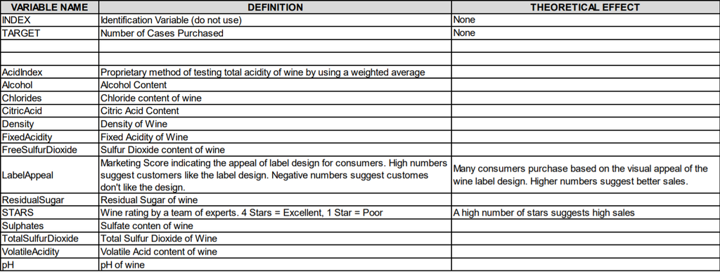

### Statistical Summary

|  | n | unique_values | min | Q.1st | median | mean | Q.3rd | max | range | sd | skew | kurtosis |
| --- | --- | --- | --- | --- | --- | --- | --- | --- | --- | --- | --- | --- |
| TARGET | 12795 | 9 | 0 | 2 | 3 | 3.03 | 4 | 8 | 8 | 1.93 | -0.33 | -0.88 |
| FixedAcidity | 12795 | 470 | -18.1 | 5.2 | 6.9 | 7.08 | 9.5 | 34.4 | 52.5 | 6.32 | -0.02 | 1.67 |
| VolatileAcidity | 12795 | 815 | -2.79 | 0.13 | 0.28 | 0.32 | 0.64 | 3.68 | 6.47 | 0.78 | 0.02 | 1.83 |
| CitricAcid | 12795 | 602 | -3.24 | 0.03 | 0.31 | 0.31 | 0.58 | 3.86 | 7.1 | 0.86 | -0.05 | 1.84 |
| ResidualSugar | 12179 | 2078 | -127.8 | -2 | 3.9 | 5.42 | 15.9 | 141.15 | 268.95 | 33.75 | -0.05 | 1.88 |
| Chlorides | 12157 | 1664 | -1.17 | -0.03 | 0.05 | 0.05 | 0.15 | 1.35 | 2.52 | 0.32 | 0.03 | 1.79 |
| FreeSulfurDioxide | 12148 | 1000 | -555 | 0 | 30 | 30.85 | 70 | 623 | 1178 | 148.71 | 0.01 | 1.84 |
| TotalSulfurDioxide | 12113 | 1371 | -823 | 27 | 123 | 120.71 | 208 | 1057 | 1880 | 231.91 | -0.01 | 1.67 |
| Density | 12795 | 5933 | 0.89 | 0.99 | 0.99 | 0.99 | 1 | 1.1 | 0.21 | 0.03 | -0.02 | 1.9 |
| pH | 12400 | 498 | 0.48 | 2.96 | 3.2 | 3.21 | 3.47 | 6.13 | 5.65 | 0.68 | 0.04 | 1.65 |

[output cut: 5 more lines]

## Visualizations

### Discrete variables

#### Frequencies

In the barplots below, we notice that more than 20% of the `TARGET` values are zero, which indicates that the data may be a good candidate for a zero-inflated Poisson regression model.

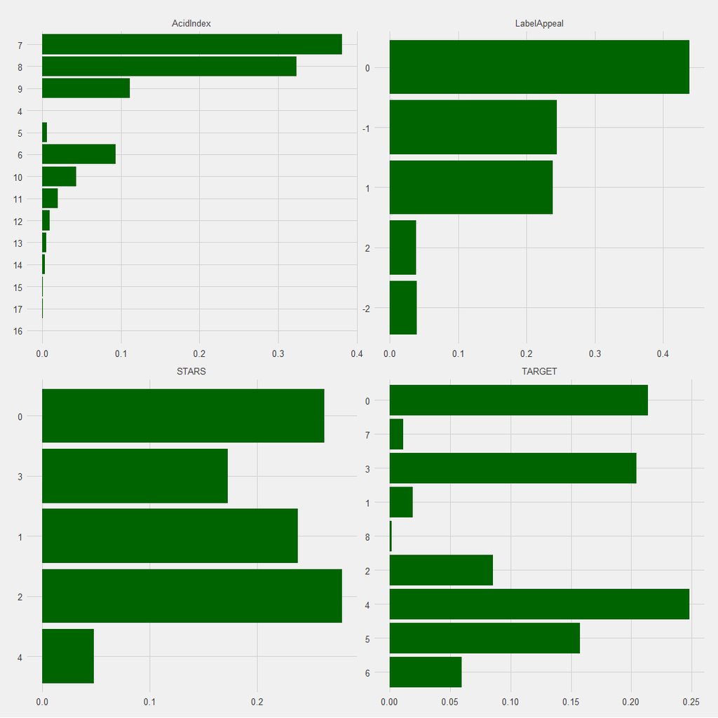

#### Side-by-Side Boxplots

The box plots contain the `TARGET` distributions for each of the discrete variable values. As we expected, higher values of `LabelAppeal` and `STARS` are associated with more wine being purchased. Additionally, smaller `AcidIndex` values appear to be associated with more wine purchases.

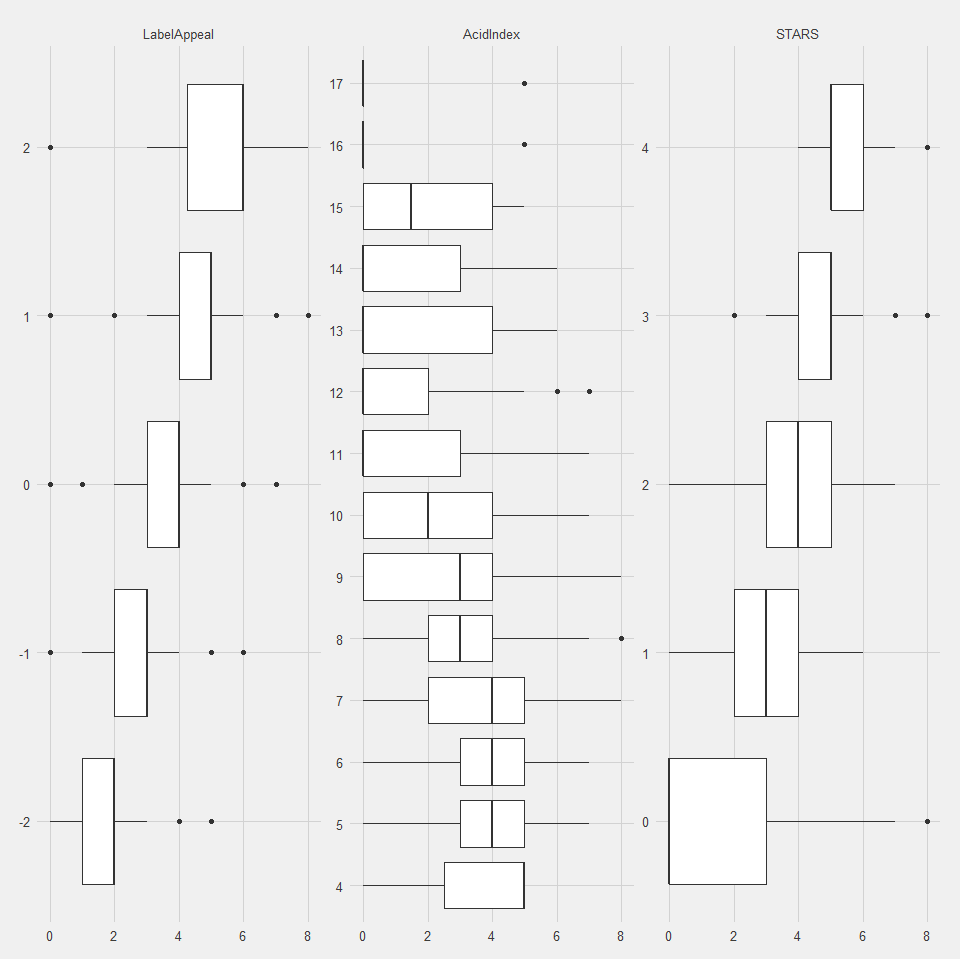

## All Variables

### Histograms of Continuous Variables

```
## Using  as id variables
```

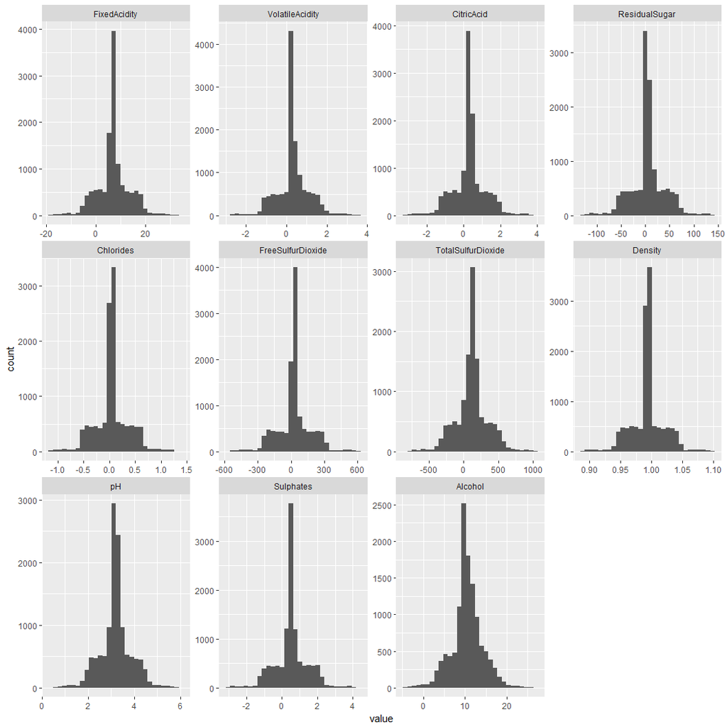

### Correlations

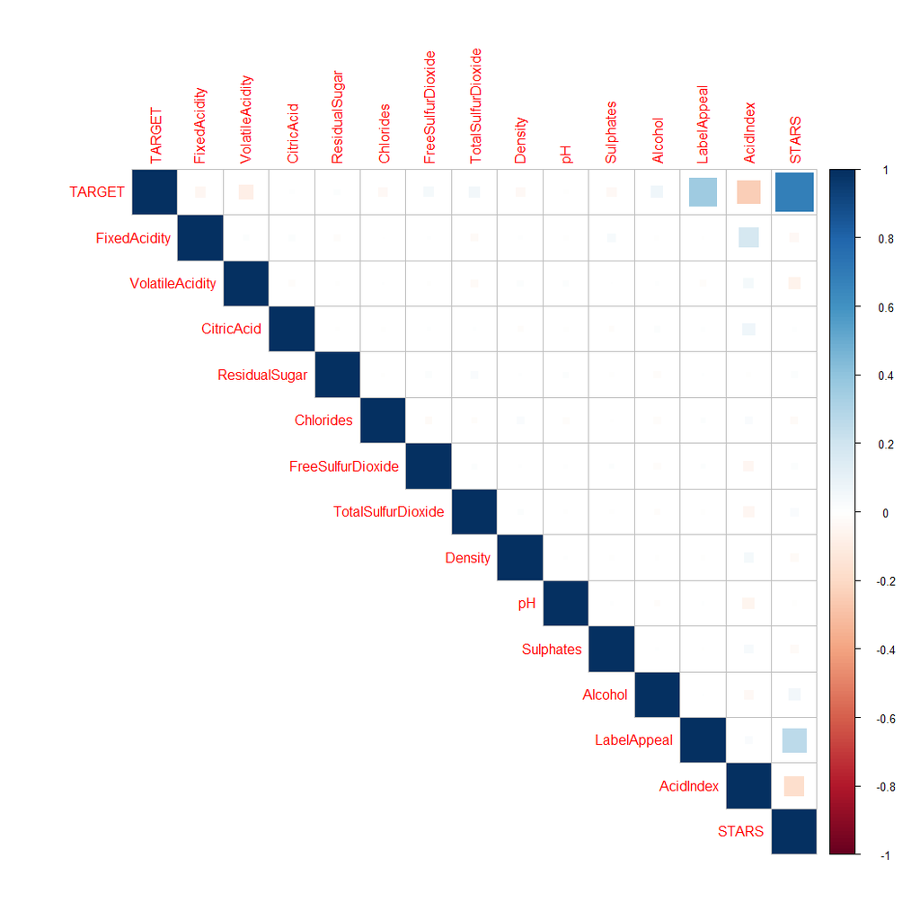

Top Correlated Variable Pairs

|  | Var1 | Var2 | Correlation | Rsquared |
| --- | --- | --- | --- | --- |
| 1 | TARGET | STARS | 0.69 | 0.47 |
| 2 | TARGET | LabelAppeal | 0.36 | 0.13 |
| 3 | LabelAppeal | STARS | 0.26 | 0.07 |
| 4 | TARGET | AcidIndex | -0.25 | 0.06 |
| 5 | FixedAcidity | AcidIndex | 0.18 | 0.03 |

Top Corrrelations with the Response Variable

|  | Var1 | Var2 | Correlation | Rsquared |
| --- | --- | --- | --- | --- |
| 1 | TARGET | STARS | 0.69 | 0.47 |
| 2 | TARGET | LabelAppeal | 0.36 | 0.13 |
| 3 | TARGET | AcidIndex | -0.25 | 0.06 |
| 4 | TARGET | VolatileAcidity | -0.09 | 0.01 |
| 5 | TARGET | Alcohol | 0.06 | 0.00 |

## Missing Values

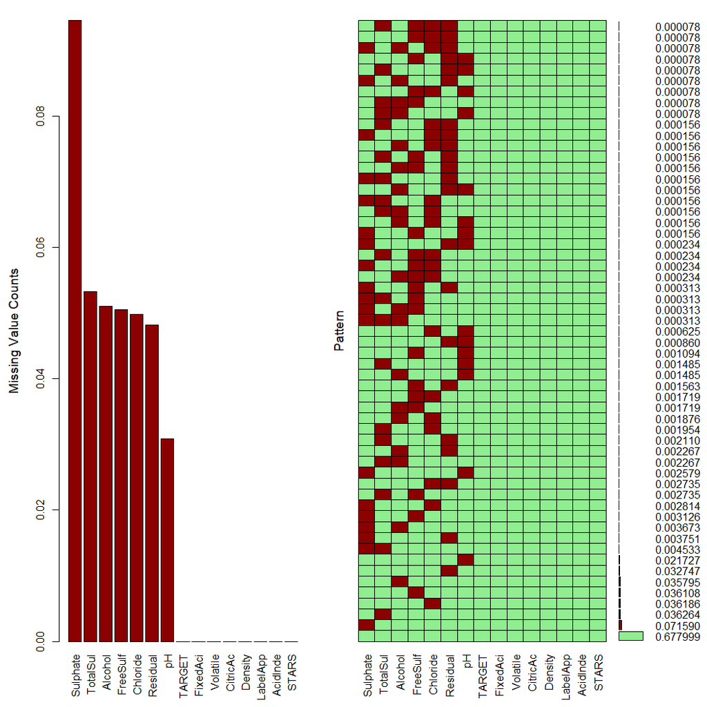

# 3. BUILD MODELS

Using the training data set, build at least two different poisson regression models, at least two different negative binomial regression models, and at least two multiple linear regression models, using different variables